# Analysis of Voter Trends in the United States of America

### Rohan Dewan, Fall 2024 CMSC 320 Project

# Introduction

As a Computer Science and Political Science dual degree, I'm often posed with the question what are the largest intersections between my fields of study? Following the 2024 United States General Election, Political Science has never been more scrutinized. Many pundits, scholars, and voters alike have wondered how decisions were so incorrectly made, predictions fell so far from the truth, and campaign strategies had such unexpected results. Nuanced social science analysis is the backbone of political understanding, however, the randomness of election results shows that quantitative, scientific understanding is needed more than ever.

I wanted to do a political investigation for this datascience project. I intend to use election data over the last 50 or so years in presidential, sentate, and house elections to determine what political practices are best, how we can follow and predict trends, and what different campaigns/parties can do to shore up support moving forward. Some questions that I wish to answer (among others) include:

- How do midterm elections predict presidential elections in the next cycle (and vice versa)?
- How to different population sizes vote and what can political campaigns do to attract these demographics in the future?
- Do any political parties show dominance over the others and if so, how has it evolved?

Throughout this tutorial, I will properly clean my data, make preliminary observations, feature engineer, and apply machine learning methods to create recommendation and prediction models. Paired with my data visualizations, I'll use all my findings to make policy suggestions that political groups and parties can use in future elections. In this new era of political uncertainty, these findings will prove vital.

# Data Curation

```python
# These are the tools and libraries I will make use of throughout the project
import numpy as np
from numpy.polynomial.polynomial import Polynomial
from scipy.optimize import curve_fit
import pandas as pd
import matplotlib.pyplot as plt
import requests
from bs4 import BeautifulSoup
import warnings
import seaborn as sns
from io import StringIO
import math
import datetime as dt
import scipy.stats as stats
from sklearn.model_selection import train_test_split, GridSearchCV, cross_val_score
from sklearn.ensemble import GradientBoostingRegressor, RandomForestClassifier
from sklearn.metrics import mean_squared_error, r2_score, accuracy_score, classification_report, confusion_matrix
from sklearn.preprocessing import LabelEncoder
import seaborn as sns
from scipy.stats import chi2_contingency
```

**Below, we will import a csv that has all presidential election data from 1976 to 2020**

```python
president_df = pd.read_csv('/content/drive/MyDrive/320 Datasets/1976-2020-president.csv')
print(president_df.shape)
president_df.head(10)
```

```
(4287, 15)
```

|  | year | state | state_po | state_fips | state_cen | state_ic | office | candidate | party_detailed | writein | candidatevotes | totalvotes | version | notes | party_simplified |
| --- | --- | --- | --- | --- | --- | --- | --- | --- | --- | --- | --- | --- | --- | --- | --- |
| 0 | 1976 | ALABAMA | AL | 1 | 63 | 41 | US PRESIDENT | CARTER, JIMMY | DEMOCRAT | False | 659170 | 1182850 | 20210113 | NaN | DEMOCRAT |
| 1 | 1976 | ALABAMA | AL | 1 | 63 | 41 | US PRESIDENT | FORD, GERALD | REPUBLICAN | False | 504070 | 1182850 | 20210113 | NaN | REPUBLICAN |
| 2 | 1976 | ALABAMA | AL | 1 | 63 | 41 | US PRESIDENT | MADDOX, LESTER | AMERICAN INDEPENDENT PARTY | False | 9198 | 1182850 | 20210113 | NaN | OTHER |
| 3 | 1976 | ALABAMA | AL | 1 | 63 | 41 | US PRESIDENT | BUBAR, BENJAMIN ""BEN"" | PROHIBITION | False | 6669 | 1182850 | 20210113 | NaN | OTHER |
| 4 | 1976 | ALABAMA | AL | 1 | 63 | 41 | US PRESIDENT | HALL, GUS | COMMUNIST PARTY USE | False | 1954 | 1182850 | 20210113 | NaN | OTHER |
| 5 | 1976 | ALABAMA | AL | 1 | 63 | 41 | US PRESIDENT | MACBRIDE, ROGER | LIBERTARIAN | False | 1481 | 1182850 | 20210113 | NaN | LIBERTARIAN |
| 6 | 1976 | ALABAMA | AL | 1 | 63 | 41 | US PRESIDENT | NaN | NaN | True | 308 | 1182850 | 20210113 | NaN | OTHER |
| 7 | 1976 | ALASKA | AK | 2 | 94 | 81 | US PRESIDENT | FORD, GERALD | REPUBLICAN | False | 71555 | 123574 | 20210113 | NaN | REPUBLICAN |
| 8 | 1976 | ALASKA | AK | 2 | 94 | 81 | US PRESIDENT | CARTER, JIMMY | DEMOCRAT | False | 44058 | 123574 | 20210113 | NaN | DEMOCRAT |
| 9 | 1976 | ALASKA | AK | 2 | 94 | 81 | US PRESIDENT | MACBRIDE, ROGER | LIBERTARIAN | False | 6785 | 123574 | 20210113 | NaN | LIBERTARIAN |

**Below, we will import a csv that has all house election data from 1976 to 2022**

```python
house_df = pd.read_csv('/content/drive/MyDrive/320 Datasets/1976-2022-house.csv')
print(house_df.shape)
house_df.head(10)
```

```
(32452, 20)
```

|  | year | state | state_po | state_fips | state_cen | state_ic | office | district | stage | runoff | special | candidate | party | writein | mode | candidatevotes | totalvotes | unofficial | version | fusion_ticket |
| --- | --- | --- | --- | --- | --- | --- | --- | --- | --- | --- | --- | --- | --- | --- | --- | --- | --- | --- | --- | --- |
| 0 | 1976 | ALABAMA | AL | 1 | 63 | 41 | US HOUSE | 1 | GEN | False | False | BILL DAVENPORT | DEMOCRAT | False | TOTAL | 58906 | 157170 | False | 20230706 | False |
| 1 | 1976 | ALABAMA | AL | 1 | 63 | 41 | US HOUSE | 1 | GEN | False | False | JACK EDWARDS | REPUBLICAN | False | TOTAL | 98257 | 157170 | False | 20230706 | False |
| 2 | 1976 | ALABAMA | AL | 1 | 63 | 41 | US HOUSE | 1 | GEN | False | False | WRITEIN | NaN | True | TOTAL | 7 | 157170 | False | 20230706 | False |
| 3 | 1976 | ALABAMA | AL | 1 | 63 | 41 | US HOUSE | 2 | GEN | False | False | J CAROLE KEAHEY | DEMOCRAT | False | TOTAL | 66288 | 156362 | False | 20230706 | False |
| 4 | 1976 | ALABAMA | AL | 1 | 63 | 41 | US HOUSE | 2 | GEN | False | False | WILLIAM L "BILL" DICKINSON | REPUBLICAN | False | TOTAL | 90069 | 156362 | False | 20230706 | False |
| 5 | 1976 | ALABAMA | AL | 1 | 63 | 41 | US HOUSE | 2 | GEN | False | False | WRITEIN | NaN | True | TOTAL | 5 | 156362 | False | 20230706 | False |
| 6 | 1976 | ALABAMA | AL | 1 | 63 | 41 | US HOUSE | 3 | GEN | False | False | BILL NICHOLS | DEMOCRAT | False | TOTAL | 106935 | 108048 | False | 20230706 | False |
| 7 | 1976 | ALABAMA | AL | 1 | 63 | 41 | US HOUSE | 3 | GEN | False | False | OGBURN GARDNER | PROHIBITION | False | TOTAL | 1111 | 108048 | False | 20230706 | False |
| 8 | 1976 | ALABAMA | AL | 1 | 63 | 41 | US HOUSE | 3 | GEN | False | False | WRITEIN | NaN | True | TOTAL | 2 | 108048 | False | 20230706 | False |
| 9 | 1976 | ALABAMA | AL | 1 | 63 | 41 | US HOUSE | 4 | GEN | False | False | LEONARD WILSON | REPUBLICAN | False | TOTAL | 34531 | 176022 | False | 20230706 | False |

```python
senate_df = pd.read_csv('/content/drive/MyDrive/320 Datasets/1976-2020-senate.csv')
print(senate_df.shape)
senate_df.head(10)
```

```
(3629, 19)
```

|  | year | state | state_po | state_fips | state_cen | state_ic | office | district | stage | special | candidate | party_detailed | writein | mode | candidatevotes | totalvotes | unofficial | version | party_simplified |
| --- | --- | --- | --- | --- | --- | --- | --- | --- | --- | --- | --- | --- | --- | --- | --- | --- | --- | --- | --- |
| 0 | 1976 | ARIZONA | AZ | 4 | 86 | 61 | US SENATE | statewide | gen | False | SAM STEIGER | REPUBLICAN | False | total | 321236 | 741210 | False | 20210114 | REPUBLICAN |
| 1 | 1976 | ARIZONA | AZ | 4 | 86 | 61 | US SENATE | statewide | gen | False | WM. MATHEWS FEIGHAN | INDEPENDENT | False | total | 1565 | 741210 | False | 20210114 | OTHER |
| 2 | 1976 | ARIZONA | AZ | 4 | 86 | 61 | US SENATE | statewide | gen | False | DENNIS DECONCINI | DEMOCRAT | False | total | 400334 | 741210 | False | 20210114 | DEMOCRAT |
| 3 | 1976 | ARIZONA | AZ | 4 | 86 | 61 | US SENATE | statewide | gen | False | ALLAN NORWITZ | LIBERTARIAN | False | total | 7310 | 741210 | False | 20210114 | LIBERTARIAN |
| 4 | 1976 | ARIZONA | AZ | 4 | 86 | 61 | US SENATE | statewide | gen | False | BOB FIELD | INDEPENDENT | False | total | 10765 | 741210 | False | 20210114 | OTHER |
| 5 | 1976 | CALIFORNIA | CA | 6 | 93 | 71 | US SENATE | statewide | gen | False | JACK MCCOY | AMERICAN INDEPENDENT | False | total | 82739 | 7470586 | False | 20210114 | OTHER |
| 6 | 1976 | CALIFORNIA | CA | 6 | 93 | 71 | US SENATE | statewide | gen | False | S. I. (SAM) HAYAKAWA | REPUBLICAN | False | total | 3748973 | 7470586 | False | 20210114 | REPUBLICAN |
| 7 | 1976 | CALIFORNIA | CA | 6 | 93 | 71 | US SENATE | statewide | gen | False | JOHN V. TUNNEY | DEMOCRAT | False | total | 3502862 | 7470586 | False | 20210114 | DEMOCRAT |
| 8 | 1976 | CALIFORNIA | CA | 6 | 93 | 71 | US SENATE | statewide | gen | False | OMARI MUSA | INDEPENDENT | False | total | 31629 | 7470586 | False | 20210114 | OTHER |
| 9 | 1976 | CALIFORNIA | CA | 6 | 93 | 71 | US SENATE | statewide | gen | False | DAVID WALD | PEACE AND FREEDOM | False | total | 104383 | 7470586 | False | 20210114 | OTHER |

```python
# I've used some features that are soon to be depracated, so to avoid reader confusion I will suppress errors
# I already accoutned and addressed all errors that would affect my output and project quality
warnings.filterwarnings('ignore')
```

I also want to find population data for different states. This information may be helpful later on in our exploratory and primary analysis. To do this, I'll webscrape from https://www.census.gov/data/tables/time-series/dec/popchange-data-text.html. A helpful tool that you can use for this is the Beautiful Soup Python library which you can read more about here: https://www.crummy.com/software/BeautifulSoup/bs4/doc/.

```python
# Extracting information from census.gov
url = "https://www.census.gov/data/tables/time-series/dec/popchange-data-text.html"
response = requests.get(url)
if response.status_code == 200:
    print("Successfully fetched the webpage")
else:
    print(f"Failed to fetch the webpage: {response.status_code}")
    exit()

# Parse the HTML content
soup = BeautifulSoup(response.content, 'html.parser')
tables = soup.find_all('table')

dataframes = []
for i, table in enumerate(tables):
    # Use StringIO to handle HTML as a file-like object
    table_html = str(table)
    population_df = pd.read_html(StringIO(table_html))[0]
    dataframes.append(population_df)
    print(f"Processed table {i + 1}")

# Storing CSV to avoid going through the entire webscraping process again later is a good idea for maintenance and efficiency if ever required
for i, df in enumerate(dataframes):
    df.to_csv(f"table_{i + 1}.csv", index=False)

population_df
```

```
Successfully fetched the webpage
Processed table 1
```

|  | State or Region | 2020 Census | 2010 Census | 2000 Census | 1990 Census | 1980 Census | 1970 Census | 1960 Census | 1950 Census | 1940 Census | 1930 Census | 1920 Census | 1910 Census |
| --- | --- | --- | --- | --- | --- | --- | --- | --- | --- | --- | --- | --- | --- |
| 0 | United States | United States | United States | United States | United States | United States | United States | United States | United States | United States | United States | United States | United States |
| 1 | Resident Population | 331449281 | 308745538 | 281421906 | 248709873 | 226545805 | 203211926 | 179323175 | 151325798 | 132165129 | 123202660 | 106021568 | 92228531 |
| 2 | Percent Change | 7.4% | 9.7% | 13.2% | 9.8% | 11.5% | 13.3% | 18.5% | 14.5% | 7.3% | 16.2% | 15.0% | 21.0% |
| 3 | Northeast | Northeast | Northeast | Northeast | Northeast | Northeast | Northeast | Northeast | Northeast | Northeast | Northeast | Northeast | Northeast |
| 4 | Resident Population | 57609148 | 55317240 | 53594378 | 50809229 | 49135283 | 49040703 | 44677819 | 39477986 | 35976777 | 34427091 | 29662053 | 25868573 |
| ... | ... | ... | ... | ... | ... | ... | ... | ... | ... | ... | ... | ... | ... |
| 166 | Resident Population | 576851 | 563626 | 493782 | 453588 | 469557 | 332416 | 330066 | 290529 | 250742 | 225565 | 194402 | 145965 |
| 167 | Percent Change | 2.3% | 14.1% | 8.9% | -3.4% | 41.3% | 0.7% | 13.6% | 15.9% | 11.2% | 16.0% | 33.2% | 57.7% |
| 168 | Puerto Rico | Puerto Rico | Puerto Rico | Puerto Rico | Puerto Rico | Puerto Rico | Puerto Rico | Puerto Rico | Puerto Rico | Puerto Rico | Puerto Rico | Puerto Rico | Puerto Rico |
| 169 | Resident Population | 3285874 | 3725789 | 3808610 | 3522037 | 3196520 | 2712033 | 2349544 | 2210703 | 1869255 | 1543913 | 1299809 | 1118012 |
| 170 | Percent Change | -11.8% | -2.2% | 8.1% | 10.2% | 17.9% | 15.4% | 6.3% | 18.3% | 21.1% | 18.8% | 16.3% | 17.3% |

171 rows × 13 columns

# **Cleaning Data**

Often in data science projects, the standard procedure is to convert date and time into NumPy's datetime format for more functionality and standardization. However, since we are only dealing with election years and not more specific date or time information, we can leave this field/feature in int64 for all of our dataframes. Everything else will be stored in string form.

```python
# Make a copy of the DataFrame to avoid modifying a slice
president_df = president_df.copy()

# Make sure the values are the correct data types
for col in president_df.columns:
    if president_df[col].dtype == 'object':
        president_df[col] = president_df[col].astype('str')
president_df['writein'] = president_df['writein'].map({'True': True, 'False': False})

# Filter out writein rows and other irrelevant columns that woud complicate our analysis
president_df = president_df[president_df['writein'] == False]
president_df = president_df.drop(columns=['writein', 'party_detailed', 'version', 'notes', 'state_fips', 'state_cen', 'state_ic'])

president_df = president_df.groupby(['year', 'state'], group_keys=False).apply(lambda x: x.nlargest(3, 'candidatevotes'))
president_df.reset_index(drop=True, inplace=True)
president_df.rename(columns={'party_simplified': 'party'}, inplace=True)

# Reduce analysis to three party categories
president_df['party'] = np.where(president_df['party'].isin(['DEMOCRAT', 'REPUBLICAN']), president_df['party'], 'OTHER')

president_df
```

|  | year | state | state_po | office | candidate | candidatevotes | totalvotes | party |
| --- | --- | --- | --- | --- | --- | --- | --- | --- |
| 0 | 1976 | ALABAMA | AL | US PRESIDENT | CARTER, JIMMY | 659170 | 1182850 | DEMOCRAT |
| 1 | 1976 | ALABAMA | AL | US PRESIDENT | FORD, GERALD | 504070 | 1182850 | REPUBLICAN |
| 2 | 1976 | ALABAMA | AL | US PRESIDENT | MADDOX, LESTER | 9198 | 1182850 | OTHER |
| 3 | 1976 | ALASKA | AK | US PRESIDENT | FORD, GERALD | 71555 | 123574 | REPUBLICAN |
| 4 | 1976 | ALASKA | AK | US PRESIDENT | CARTER, JIMMY | 44058 | 123574 | DEMOCRAT |
| ... | ... | ... | ... | ... | ... | ... | ... | ... |
| 1821 | 2020 | WISCONSIN | WI | US PRESIDENT | TRUMP, DONALD J. | 1610184 | 3298041 | REPUBLICAN |
| 1822 | 2020 | WISCONSIN | WI | US PRESIDENT | JORGENSEN, JO | 38491 | 3298041 | OTHER |
| 1823 | 2020 | WYOMING | WY | US PRESIDENT | TRUMP, DONALD J. | 193559 | 278503 | REPUBLICAN |
| 1824 | 2020 | WYOMING | WY | US PRESIDENT | BIDEN, JOSEPH R. JR | 73491 | 278503 | DEMOCRAT |
| 1825 | 2020 | WYOMING | WY | US PRESIDENT | JORGENSEN, JO | 5768 | 278503 | OTHER |

1826 rows × 8 columns

```python
# Copy dataframe to avoid modifying a slice
house_df = house_df.copy()

for col in house_df.columns:
    if house_df[col].dtype == 'object':
        house_df[col] = house_df[col].astype('str')

# Exclude fusion ticket rows because complicates our analysis
house_df = house_df[house_df['fusion_ticket'] == False]

# The datasets have many additional columns about election particulars that will not be important for our analysis
house_df.drop(columns=['writein', 'special', 'mode', 'unofficial', 'state_fips', 'state_cen', 'state_ic', 'version', 'runoff', 'fusion_ticket'], inplace=True)

house_df = house_df.groupby(['year', 'state_po', 'district'], group_keys=False).apply(lambda x: x.nlargest(3, 'candidatevotes'))
house_df.reset_index(drop=True, inplace=True)

# Filter out "WRITEIN" candidates
house_df = house_df[house_df['candidate'] != "WRITEIN"]

# Use .loc to avoid the SettingWithCopyWarning
house_df.loc[:, 'party'] = np.where(house_df['party'].isin(['DEMOCRAT', 'REPUBLICAN']), house_df['party'], 'OTHER')

# Reduce analysis to three party categories
house_df['party'] = np.where(house_df['party'].isin(['DEMOCRAT', 'REPUBLICAN']), house_df['party'], 'OTHER')

house_df
```

|  | year | state | state_po | office | district | stage | candidate | party | candidatevotes | totalvotes |
| --- | --- | --- | --- | --- | --- | --- | --- | --- | --- | --- |
| 0 | 1976 | ALASKA | AK | US HOUSE | 0 | GEN | DON YOUNG | REPUBLICAN | 83722 | 118208 |
| 1 | 1976 | ALASKA | AK | US HOUSE | 0 | GEN | EBEN HOPSON | DEMOCRAT | 34194 | 118208 |
| 3 | 1976 | ALABAMA | AL | US HOUSE | 1 | GEN | JACK EDWARDS | REPUBLICAN | 98257 | 157170 |
| 4 | 1976 | ALABAMA | AL | US HOUSE | 1 | GEN | BILL DAVENPORT | DEMOCRAT | 58906 | 157170 |
| 6 | 1976 | ALABAMA | AL | US HOUSE | 2 | GEN | WILLIAM L "BILL" DICKINSON | REPUBLICAN | 90069 | 156362 |
| ... | ... | ... | ... | ... | ... | ... | ... | ... | ... | ... |
| 26002 | 2022 | WEST VIRGINIA | WV | US HOUSE | 2 | GEN | BARRY LEE WENDELL | DEMOCRAT | 84278 | 244886 |
| 26003 | 2022 | WEST VIRGINIA | WV | US HOUSE | 2 | GEN | SUSAN BUCHSER-LOCHOCKI | OTHER | 115 | 244886 |
| 26004 | 2022 | WYOMING | WY | US HOUSE | 0 | GEN | HARRIET HAGEMAN | REPUBLICAN | 132206 | 198198 |
| 26005 | 2022 | WYOMING | WY | US HOUSE | 0 | GEN | LYNNETTE GREYBULL | DEMOCRAT | 47250 | 198198 |
| 26006 | 2022 | WYOMING | WY | US HOUSE | 0 | GEN | RICHARD BRUBAKER | OTHER | 5420 | 198198 |

24474 rows × 10 columns

```python
# Copy dataframe to avoid modifying a slice
senate_df = senate_df.copy()

# Convert object columns to string
for col in senate_df.columns:
    if senate_df[col].dtype == 'object':
        senate_df[col] = senate_df[col].astype('str')

# The datasets have many additional columns about election particulars that will not be important for our analysis
senate_df = senate_df[(senate_df['writein'] == False) & (senate_df['special'] == False)]
senate_df.drop(columns=['writein', 'special', 'party_detailed', 'mode', 'unofficial', 'state_fips', 'state_cen', 'state_ic'], inplace=True)

# Reduce analysis to three party categories
senate_df = senate_df.groupby(['year', 'state_po'], group_keys=False).apply(lambda x: x.nlargest(3, 'candidatevotes'))
senate_df.reset_index(drop=True, inplace=True)
senate_df.rename(columns={'party_simplified': 'party'}, inplace=True)
senate_df['party'] = np.where(senate_df['party'].isin(['DEMOCRAT', 'REPUBLICAN']), senate_df['party'], 'OTHER')

senate_df
```

|  | year | state | state_po | office | district | stage | candidate | candidatevotes | totalvotes | version | party |
| --- | --- | --- | --- | --- | --- | --- | --- | --- | --- | --- | --- |
| 0 | 1976 | ARIZONA | AZ | US SENATE | statewide | gen | DENNIS DECONCINI | 400334 | 741210 | 20210114 | DEMOCRAT |
| 1 | 1976 | ARIZONA | AZ | US SENATE | statewide | gen | SAM STEIGER | 321236 | 741210 | 20210114 | REPUBLICAN |
| 2 | 1976 | ARIZONA | AZ | US SENATE | statewide | gen | BOB FIELD | 10765 | 741210 | 20210114 | OTHER |
| 3 | 1976 | CALIFORNIA | CA | US SENATE | statewide | gen | S. I. (SAM) HAYAKAWA | 3748973 | 7470586 | 20210114 | REPUBLICAN |
| 4 | 1976 | CALIFORNIA | CA | US SENATE | statewide | gen | JOHN V. TUNNEY | 3502862 | 7470586 | 20210114 | DEMOCRAT |
| ... | ... | ... | ... | ... | ... | ... | ... | ... | ... | ... | ... |
| 2078 | 2020 | WYOMING | WY | US SENATE | statewide | gen | CYNTHIA M. LUMMIS | 198100 | 278503 | 20210114 | OTHER |
| 2079 | 2020 | WYOMING | WY | US SENATE | statewide | gen | MERAV BEN DAVID | 72766 | 278503 | 20210114 | OTHER |
| 2080 | 2020 | WYOMING | WY | US SENATE | statewide | gen | UNDER VOTES | 6401 | 278503 | 20210114 | OTHER |
| 2081 | 2021 | GEORGIA | GA | US SENATE | statewide | runoff | JON OSSOFF | 2269262 | 4483241 | 20210114 | DEMOCRAT |
| 2082 | 2021 | GEORGIA | GA | US SENATE | statewide | runoff | DAVID A. PERDUE | 2213979 | 4483241 | 20210114 | REPUBLICAN |

2083 rows × 11 columns

**We need to clean our population dataframe because webscraping leaves it in the form of the website and not our condensed and concise dataframe**

```python
# remove all regional and nationwide data that won't be applicable
rows_to_remove = range(0, 15)
population_df = population_df.drop(population_df.index[rows_to_remove])
population_df.reset_index(drop=True, inplace=True)
population_df


population_df = population_df[population_df["State or Region"] != "Percent Change"]

# forward fill function will allow us to combine the state/region row with the actual population numbers
population_df["State or Region"] = population_df["State or Region"].replace("Resident Population", pd.NA).ffill()

population_df = population_df[population_df["State or Region"] != "Resident Population"]

population_df = population_df.reset_index(drop=True)

population_df = population_df.iloc[1::2]

# We are only dealing with census reports that overlap with our datasets
population_df.drop(columns=['1910 Census', '1920 Census', '1930 Census', '1940 Census', '1950 Census', '1960 Census'], inplace=True)

population_df.rename(columns={'State or Region': 'state'}, inplace=True)
population_df.columns = population_df.columns.str.replace("Census", "", regex=True).str.strip()
population_df.reset_index(drop=True, inplace=True)
population_df = population_df.drop(index=51)

population_df['state'] = population_df['state'].str.upper()

columns_to_convert = ['2020', '2010', '2000', '1990', '1980', '1970']
population_df[columns_to_convert] = population_df[columns_to_convert].apply(lambda col: pd.to_numeric(col, errors='coerce'))

population_df
```

|  | state | 2020 | 2010 | 2000 | 1990 | 1980 | 1970 |
| --- | --- | --- | --- | --- | --- | --- | --- |
| 0 | ALABAMA | 5024279 | 4779736 | 4447100 | 4040587 | 3893888 | 3444165 |
| 1 | ALASKA | 733391 | 710231 | 626932 | 550043 | 401851 | 300382 |
| 2 | ARIZONA | 7151502 | 6392017 | 5130632 | 3665228 | 2718215 | 1770900 |
| 3 | ARKANSAS | 3011524 | 2915918 | 2673400 | 2350725 | 2286435 | 1923295 |
| 4 | CALIFORNIA | 39538223 | 37253956 | 33871648 | 29760021 | 23667902 | 19953134 |
| 5 | COLORADO | 5773714 | 5029196 | 4301261 | 3294394 | 2889964 | 2207259 |
| 6 | CONNECTICUT | 3605944 | 3574097 | 3405565 | 3287116 | 3107576 | 3031709 |
| 7 | DELAWARE | 989948 | 897934 | 783600 | 666168 | 594338 | 548104 |
| 8 | DISTRICT OF COLUMBIA | 689545 | 601723 | 572059 | 606900 | 638333 | 756510 |
| 9 | FLORIDA | 21538187 | 18801310 | 15982378 | 12937926 | 9746324 | 6789443 |
| 10 | GEORGIA | 10711908 | 9687653 | 8186453 | 6478216 | 5463105 | 4589575 |
| 11 | HAWAII | 1455271 | 1360301 | 1211537 | 1108229 | 964691 | 768561 |
| 12 | IDAHO | 1839106 | 1567582 | 1293953 | 1006749 | 943935 | 712567 |
| 13 | ILLINOIS | 12812508 | 12830632 | 12419293 | 11430602 | 11426518 | 11113976 |
| 14 | INDIANA | 6785528 | 6483802 | 6080485 | 5544159 | 5490224 | 5193669 |
| 15 | IOWA | 3190369 | 3046355 | 2926324 | 2776755 | 2913808 | 2824376 |
| 16 | KANSAS | 2937880 | 2853118 | 2688418 | 2477574 | 2363679 | 2246578 |
| 17 | KENTUCKY | 4505836 | 4339367 | 4041769 | 3685296 | 3660777 | 3218706 |
| 18 | LOUISIANA | 4657757 | 4533372 | 4468976 | 4219973 | 4205900 | 3641306 |
| 19 | MAINE | 1362359 | 1328361 | 1274923 | 1227928 | 1124660 | 992048 |
| 20 | MARYLAND | 6177224 | 5773552 | 5296486 | 4781468 | 4216975 | 3922399 |
| 21 | MASSACHUSETTS | 7029917 | 6547629 | 6349097 | 6016425 | 5737037 | 5689170 |
| 22 | MICHIGAN | 10077331 | 9883640 | 9938444 | 9295297 | 9262078 | 8875083 |
| 23 | MINNESOTA | 5706494 | 5303925 | 4919479 | 4375099 | 4075970 | 3804971 |
| 24 | MISSISSIPPI | 2961279 | 2967297 | 2844658 | 2573216 | 2520638 | 2216912 |
| 25 | MISSOURI | 6154913 | 5988927 | 5595211 | 5117073 | 4916686 | 4676501 |
| 26 | MONTANA | 1084225 | 989415 | 902195 | 799065 | 786690 | 694409 |
| 27 | NEBRASKA | 1961504 | 1826341 | 1711263 | 1578385 | 1569825 | 1483493 |
| 28 | NEVADA | 3104614 | 2700551 | 1998257 | 1201833 | 800493 | 488738 |
| 29 | NEW HAMPSHIRE | 1377529 | 1316470 | 1235786 | 1109252 | 920610 | 737681 |
| 30 | NEW JERSEY | 9288994 | 8791894 | 8414350 | 7730188 | 7364823 | 7168164 |
| 31 | NEW MEXICO | 2117522 | 2059179 | 1819046 | 1515069 | 1302894 | 1016000 |
| 32 | NEW YORK | 20201249 | 19378102 | 18976457 | 17990455 | 17558072 | 18236967 |
| 33 | NORTH CAROLINA | 10439388 | 9535483 | 8049313 | 6628637 | 5881766 | 5082059 |
| 34 | NORTH DAKOTA | 779094 | 672591 | 642200 | 638800 | 652717 | 617761 |
| 35 | OHIO | 11799448 | 11536504 | 11353140 | 10847115 | 10797630 | 10652017 |
| 36 | OKLAHOMA | 3959353 | 3751351 | 3450654 | 3145585 | 3025290 | 2559229 |
| 37 | OREGON | 4237256 | 3831074 | 3421399 | 2842321 | 2633105 | 2091385 |
| 38 | PENNSYLVANIA | 13002700 | 12702379 | 12281054 | 11881643 | 11863895 | 11793909 |
| 39 | RHODE ISLAND | 1097379 | 1052567 | 1048319 | 1003464 | 947154 | 946725 |
| 40 | SOUTH CAROLINA | 5118425 | 4625364 | 4012012 | 3486703 | 3121820 | 2590516 |
| 41 | SOUTH DAKOTA | 886667 | 814180 | 754844 | 696004 | 690768 | 665507 |
| 42 | TENNESSEE | 6910840 | 6346105 | 5689283 | 4877185 | 4591120 | 3923687 |
| 43 | TEXAS | 29145505 | 25145561 | 20851820 | 16986510 | 14229191 | 11196730 |
| 44 | UTAH | 3271616 | 2763885 | 2233169 | 1722850 | 1461037 | 1059273 |
| 45 | VERMONT | 643077 | 625741 | 608827 | 562758 | 511456 | 444330 |
| 46 | VIRGINIA | 8631393 | 8001024 | 7078515 | 6187358 | 5346818 | 4648494 |
| 47 | WASHINGTON | 7705281 | 6724540 | 5894121 | 4866692 | 4132156 | 3409169 |
| 48 | WEST VIRGINIA | 1793716 | 1852994 | 1808344 | 1793477 | 1949644 | 1744237 |
| 49 | WISCONSIN | 5893718 | 5686986 | 5363675 | 4891769 | 4705767 | 4417731 |
| 50 | WYOMING | 576851 | 563626 | 493782 | 453588 | 469557 | 332416 |

# **Exploratory Data Analysis and Data Visualization**

Exploratory Data Analysis (EDA) is a vital step for any datascience project. It allows us to understand the data better and will provide key insights into voter behavior and election dynamics across our datasets. We can identify preliminary patterns, understand distributions, and explore relationships. For more information about EDA, go here: https://www.ibm.com/topics/exploratory-data-analysis.

I'd like to see if house congressional races during the midterms are an accurate predictor for how a state will vote for the next presidential election. We can average the results of each state's house elections during the midterm to get the majority party and then see how often this party matches the winning party per vote during the subsequent presidential election.

```python
# Create a list of just the midterm elections so we can easily narrow down dataframe
midterm_years = [1978, 1982, 1986, 1990, 1994, 1998, 2002, 2006, 2010, 2014, 2018]
midterm_df = house_df[house_df['year'].isin(midterm_years)]

# I combine the votes for each election by state and party to give us a rough idea of which party "won support dominantly"
midterm_results = midterm_df.groupby(['year', 'state', 'party'])['candidatevotes'].sum().reset_index()
max_votes = midterm_results.groupby(['year', 'state'])['candidatevotes'].transform('max')
midterm_results = midterm_results[midterm_results['candidatevotes'] == max_votes]
midterm_results.reset_index(drop=True, inplace=True)
midterm_results

# Do the same thing with the presidential election years with the president df
presidential_results = president_df.groupby(['year', 'state', 'party'])['candidatevotes'].sum().reset_index()
max_votes = presidential_results.groupby(['year', 'state'])['candidatevotes'].transform('max')
presidential_results = presidential_results[presidential_results['candidatevotes'] == max_votes]

midterm_results['year'] = midterm_results['year'].astype(int) + 2

merged_df = pd.merge(midterm_results, presidential_results, on=['year', 'state'], how='inner', suffixes=('_midterm', '_presidential'))
merged_df
```

|  | year | state | party_midterm | candidatevotes_midterm | party_presidential | candidatevotes_presidential |
| --- | --- | --- | --- | --- | --- | --- |
| 0 | 1980 | ALABAMA | DEMOCRAT | 439564 | REPUBLICAN | 654192 |
| 1 | 1980 | ALASKA | REPUBLICAN | 68811 | REPUBLICAN | 86112 |
| 2 | 1980 | ARIZONA | DEMOCRAT | 261567 | REPUBLICAN | 529688 |
| 3 | 1980 | ARKANSAS | REPUBLICAN | 195371 | REPUBLICAN | 403164 |
| 4 | 1980 | CALIFORNIA | DEMOCRAT | 3335332 | REPUBLICAN | 4522994 |
| ... | ... | ... | ... | ... | ... | ... |
| 545 | 2020 | VIRGINIA | DEMOCRAT | 1867061 | DEMOCRAT | 2413568 |
| 546 | 2020 | WASHINGTON | DEMOCRAT | 1888593 | DEMOCRAT | 2369612 |
| 547 | 2020 | WEST VIRGINIA | REPUBLICAN | 337146 | REPUBLICAN | 545382 |
| 548 | 2020 | WISCONSIN | DEMOCRAT | 1367492 | DEMOCRAT | 1630866 |
| 549 | 2020 | WYOMING | REPUBLICAN | 127963 | REPUBLICAN | 193559 |

550 rows × 6 columns

```python
contingency_table = pd.crosstab(merged_df['party_midterm'], merged_df['party_presidential'])
chi2, p, dof, expected = chi2_contingency(contingency_table)
print(chi2)
print(p)
```

```
66.6028010301778
3.446557407030272e-15
```

Based on these results, we can conclude there is a significant relationship between midterm party and presidential party per state in a midterm/general election cycle. The p value is far below 0.05 so we can reject the null hypothesis that midterm majority party doesn't predict presidential majority party for each state and accept the alternative hypothesis that it does.

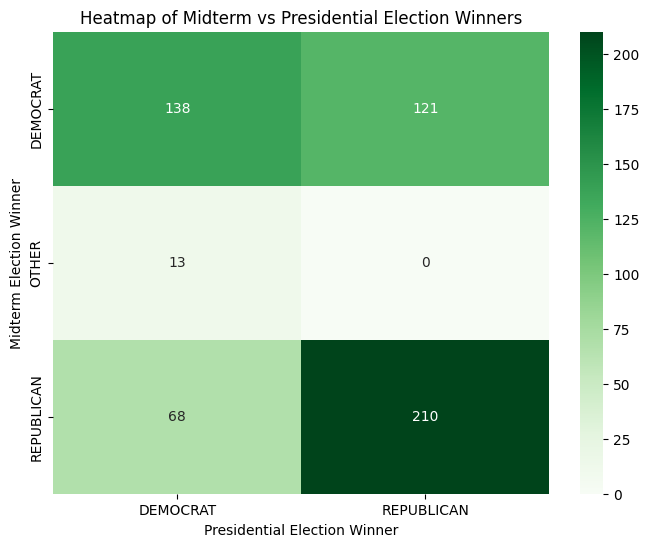

```python
heatmap_data = merged_df.pivot_table(index='party_midterm', columns='party_presidential', aggfunc='size', fill_value=0)

plt.figure(figsize=(8, 6))
sns.heatmap(heatmap_data, annot=True, fmt='d', cmap='Greens')
plt.title('Heatmap of Midterm vs Presidential Election Winners')
plt.ylabel('Midterm Election Winner')
plt.xlabel('Presidential Election Winner')
plt.show()
```

Next, I want to see if presidential, senate, and house party votes are consistent. Our null hypothesis would be that the mean vote counts for all parties across senate, house, and presidential elections are equal. Alternative hypothesis would be at least one election type has a different mean vote count.

```python
senate_total = senate_df.groupby(['year', 'party'], group_keys=False)['candidatevotes'].sum()
house_total = house_df.groupby(['year', 'party'], group_keys=False)['candidatevotes'].sum()
president_total = president_df.groupby(['year', 'party'], group_keys=False)['candidatevotes'].sum()
president_total.rename('candidatevotes_president', inplace=True)

senate_total = senate_total.reset_index()
house_total = house_total.reset_index()
president_total = president_total.reset_index()

merged_df = pd.merge(senate_total, house_total, on=['year', 'party'], how='inner', suffixes=('_senate', '_house'))
merged_df = pd.merge(merged_df, president_total, on=['year', 'party'], how='inner')
merged_df
```

|  | year | party | candidatevotes_senate | candidatevotes_house | candidatevotes_president |
| --- | --- | --- | --- | --- | --- |
| 0 | 1976 | DEMOCRAT | 31790526 | 39360210 | 40680446 |
| 1 | 1976 | OTHER | 1888824 | 1044276 | 1123524 |
| 2 | 1976 | REPUBLICAN | 24562431 | 29777957 | 38870893 |
| 3 | 1980 | DEMOCRAT | 30612805 | 37429444 | 35480948 |
| 4 | 1980 | OTHER | 1178417 | 1115481 | 5726546 |
| 5 | 1980 | REPUBLICAN | 26376614 | 35074657 | 43642639 |
| 6 | 1984 | DEMOCRAT | 22218744 | 40852918 | 37449813 |
| 7 | 1984 | OTHER | 298438 | 684132 | 607073 |
| 8 | 1984 | REPUBLICAN | 22850493 | 36386131 | 54166829 |
| 9 | 1988 | DEMOCRAT | 35137786 | 40564207 | 41716679 |
| 10 | 1988 | OTHER | 624378 | 1971362 | 748650 |
| 11 | 1988 | REPUBLICAN | 31151251 | 35337164 | 48642640 |
| 12 | 1992 | DEMOCRAT | 35225616 | 45214169 | 44856747 |
| 13 | 1992 | OTHER | 2642873 | 5970414 | 19722042 |
| 14 | 1992 | REPUBLICAN | 32429254 | 40534675 | 38798913 |
| 15 | 1996 | DEMOCRAT | 23490651 | 40765658 | 47295351 |
| 16 | 1996 | OTHER | 855153 | 2673389 | 8137979 |
| 17 | 1996 | REPUBLICAN | 24211395 | 41412837 | 39003697 |
| 18 | 2000 | DEMOCRAT | 36780875 | 42822816 | 50830580 |
| 19 | 2000 | OTHER | 1857173 | 5781034 | 3005002 |
| 20 | 2000 | REPUBLICAN | 36725431 | 44784654 | 50311372 |
| 21 | 2004 | DEMOCRAT | 43566379 | 48302670 | 58894554 |
| 22 | 2004 | OTHER | 2006423 | 5356367 | 772235 |
| 23 | 2004 | REPUBLICAN | 39920562 | 53867332 | 61872711 |
| 24 | 2008 | DEMOCRAT | 34497531 | 58762950 | 69338846 |
| 25 | 2008 | OTHER | 1673278 | 6299492 | 1051381 |
| 26 | 2008 | REPUBLICAN | 30730164 | 50328469 | 59613835 |
| 27 | 2012 | DEMOCRAT | 49988282 | 53580270 | 65752017 |
| 28 | 2012 | OTHER | 3073441 | 4657184 | 1526931 |
| 29 | 2012 | REPUBLICAN | 39128301 | 56058001 | 60670117 |
| 30 | 2016 | DEMOCRAT | 50922314 | 56378245 | 65677168 |
| 31 | 2016 | OTHER | 2748376 | 4701053 | 4907340 |
| 32 | 2016 | REPUBLICAN | 40436427 | 60280744 | 62692411 |
| 33 | 2020 | DEMOCRAT | 37936620 | 72679333 | 80951585 |
| 34 | 2020 | OTHER | 2389808 | 3279132 | 1864380 |
| 35 | 2020 | REPUBLICAN | 39845802 | 69967587 | 74197560 |

```python
senate_vote = merged_df['candidatevotes_senate']
house_vote = merged_df['candidatevotes_house']
president_vote = merged_df['candidatevotes_president']
f_statistic, p_value = stats.f_oneway(senate_vote, house_vote, president_vote)
print(p_value)
print(f_statistic)
```

```
0.03583695120975327
3.4365729083131966
```

It's clear that parties don't receive the same number of senate, house, and presidential votes in an election based on our p value less than 0.05. We can visualize the differences more with a bar graph.

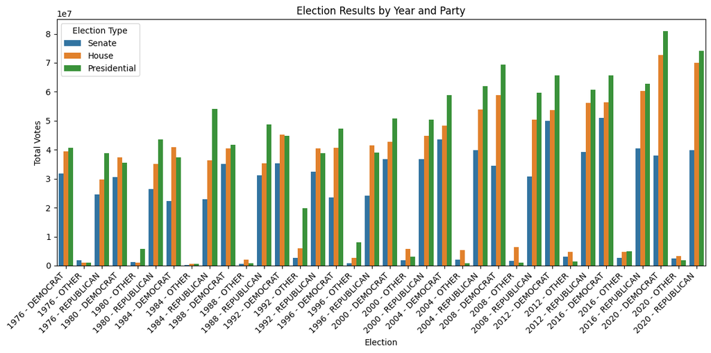

```python
merged_df.rename(columns = {
    'candidatevotes_senate': 'Senate',
    'candidatevotes_house': 'House',
    'candidatevotes_president': 'Presidential'
}, inplace=True)

# Melt the DataFrame for easier plotting
long_df = pd.melt(merged_df, id_vars=['year', 'party'],
                  value_vars=['Senate', 'House', 'Presidential'],
                  var_name='Election_Type', value_name='Votes')

# Create a new column for better x-axis labeling
long_df['Election'] = long_df['year'].astype(str) + ' - ' + long_df['party']

# Plotting
plt.figure(figsize=(12, 6))
sns.barplot(data=long_df, x='Election', y='Votes', hue='Election_Type', errorbar=None)

# Customize plot
plt.title('Election Results by Year and Party')
plt.ylabel('Total Votes')
plt.xticks(rotation=45, ha='right')
plt.legend(title='Election Type', loc='upper left')
plt.tight_layout()
plt.show()
```

From this graph we can see that dominance in one field does not necessarily translates to dominance in the other two. Parties may perform far better in a presidential race but lose to the other in the house and senate. This shows that we will need to perform more nuanced machine learning to understand why this is and extract meaningful trends.

Next, we will do a simple test to see if republicans have on average a greater share of the senate and house vote than democrats do by comparing all house and senate elections between and seeing if the republican average is statistically signficantly larger.

```python
house_adjusted = house_df[house_df['party'] != "OTHER"]
senate_adjusted = senate_df[senate_df['party'] != "OTHER"]

house_adjusted.drop(columns={'state_po', 'district', 'stage', 'candidate'})
dem_house = house_adjusted[house_adjusted['party'] == 'DEMOCRAT']['candidatevotes']
rep_house = house_adjusted[house_adjusted['party'] == 'REPUBLICAN']['candidatevotes']
t_house, p_house = stats.ttest_ind(rep_house, dem_house, alternative='greater')
print(p_house)
print(t_house)

senate_adjusted
senate_adjusted.drop(columns={'state_po', 'office', 'district', 'candidate', 'version'})
dem_senate = senate_adjusted[senate_adjusted['party'] == 'DEMOCRAT']['candidatevotes']
rep_senate = senate_adjusted[senate_adjusted['party'] == 'REPUBLICAN']['candidatevotes']
t_senate, p_senate = stats.ttest_ind(rep_senate, dem_senate, alternative='greater')
print(p_senate)
print(t_senate)
```

```
0.7755366151331108
-0.7572216549189181
0.9617772708402228
-1.7729131744810809
```

Based on our two t-tests, we see that there is no statistical signficance with a massive p-value so we can't reject our null hypothesis for either test. Thus, it stands that both the Republican houe and senate average vote is less than or equal to the Democratic one.

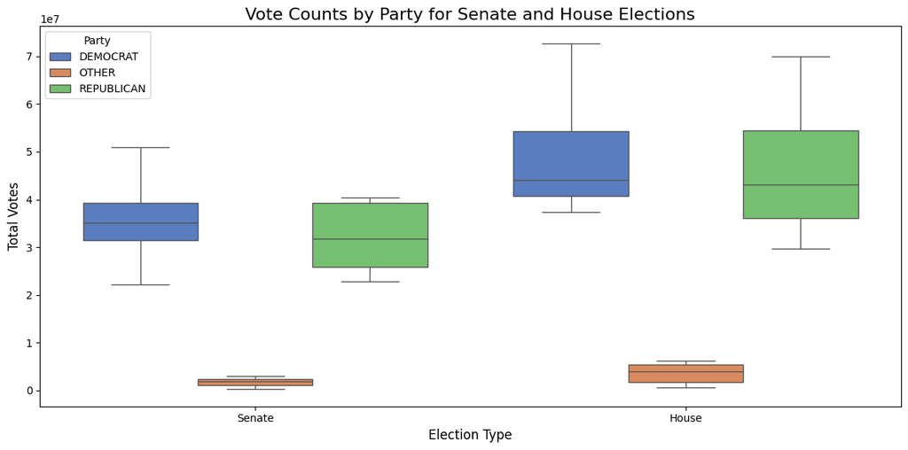

```python
long_df = pd.melt(merged_df, id_vars=['year', 'party'],
                  value_vars=['Senate', 'House'],
                  var_name='Election_Type', value_name='Votes')

plt.figure(figsize=(12, 6))
sns.boxplot(x='Election_Type', y='Votes', hue='party', data=long_df, palette='muted')

plt.title('Vote Counts by Party for Senate and House Elections', fontsize=16)
plt.xlabel('Election Type', fontsize=12)
plt.ylabel('Total Votes', fontsize=12)
plt.legend(title='Party')
plt.tight_layout()
plt.show()
```

What's interesting from this plot is that we see the upper bounds for the interquartial ranges of both parties in both types of legislative elections are extremely similar. However, the Republicans have much lower lower bounds for the IQRs. The max and min values for the house also indicat the the Democrats have had more blowout victories in the past compared to the Republicans. The senate is slightly more even except for a larger max value for the Democrats. Still, this is very aggregated information so we need to perform for specific machine learning and primary data analysis.

**Before proceeding, it also makes sense to look at average voting trends over time for each type of election**

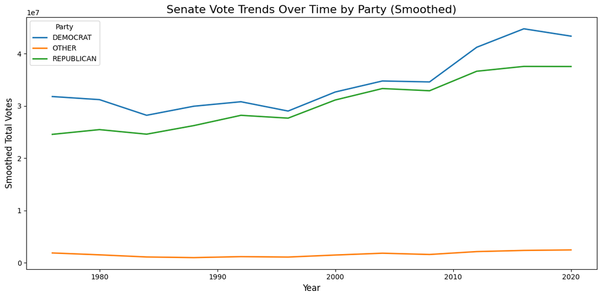

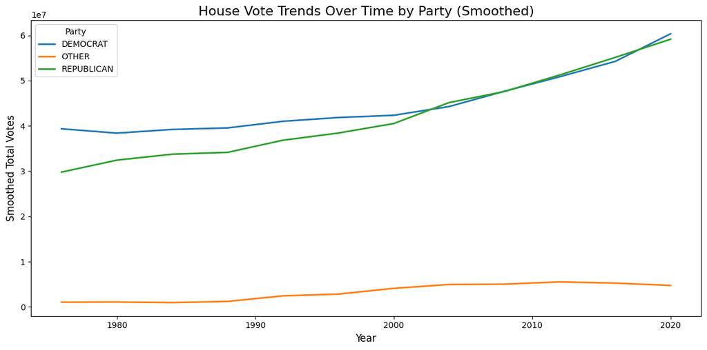

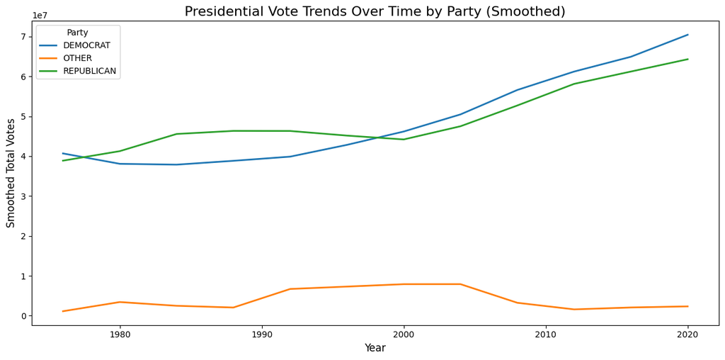

```python
# Ensure no NaN values in Votes after melting
long_df_trend = pd.melt(
    merged_df,
    id_vars=['year', 'party'],
    value_vars=['Senate', 'House', 'Presidential'],
    var_name='Election_Type',
    value_name='Votes'
)

# Drop any rows with missing Votes
long_df_trend = long_df_trend.dropna(subset=['Votes'])

# Add a rolling average to smooth trends
long_df_trend['Rolling_Avg'] = long_df_trend.groupby(['party', 'Election_Type'])['Votes'].transform(
    lambda x: x.rolling(window=4, min_periods=1).mean()
)

# Separate data for each election type
senate_trend = long_df_trend[long_df_trend['Election_Type'] == 'Senate']
house_trend = long_df_trend[long_df_trend['Election_Type'] == 'House']
presidential_trend = long_df_trend[long_df_trend['Election_Type'] == 'Presidential']

# Function to plot trends
def plot_trends(data, title):
    plt.figure(figsize=(12, 6))
    sns.lineplot(data=data, x='year', y='Rolling_Avg', hue='party', linewidth=2, markers=True)
    plt.title(title, fontsize=16)
    plt.xlabel('Year', fontsize=12)
    plt.ylabel('Smoothed Total Votes', fontsize=12)
    plt.legend(title='Party')
    plt.tight_layout()
    plt.show()

# Call for each election type
plot_trends(senate_trend, 'Senate Vote Trends Over Time by Party (Smoothed)')
plot_trends(house_trend, 'House Vote Trends Over Time by Party (Smoothed)')
plot_trends(presidential_trend, 'Presidential Vote Trends Over Time by Party (Smoothed)')
```

I'll also explore the averaged margins for for election type and party of victory in past elections to see if one party has a more decisive advantage over the other in their wins.

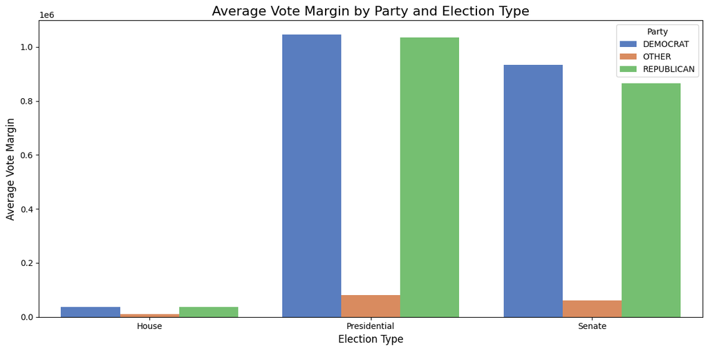

```python
# Function to calculate the vote margin
def calculate_margin(df):
    df = df.sort_values(by='candidatevotes', ascending=False)
    top_votes = df.iloc[0]['candidatevotes']
    second_votes = df.iloc[1]['candidatevotes'] if len(df) > 1 else 0
    return top_votes - second_votes

# Calculate margins for each election type (president, house, senate)
president_margin = president_df.groupby(['year', 'state', 'party']).apply(calculate_margin).reset_index(name='Vote Margin')
house_margin = house_df.groupby(['year', 'state', 'party']).apply(calculate_margin).reset_index(name='Vote Margin')
senate_margin = senate_df.groupby(['year', 'state', 'party']).apply(calculate_margin).reset_index(name='Vote Margin')

# Add election type column
president_margin['Election_Type'] = 'Presidential'
house_margin['Election_Type'] = 'House'
senate_margin['Election_Type'] = 'Senate'

margin_df = pd.concat([president_margin, house_margin, senate_margin])
merged_margin_df = pd.merge(margin_df, pd.concat([president_df, house_df, senate_df]), on=['year', 'state', 'party'], how='inner')
avg_margin_df = margin_df.groupby(['Election_Type', 'party'])['Vote Margin'].mean().reset_index()

plt.figure(figsize=(12, 6))
sns.barplot(data=avg_margin_df, x='Election_Type', y='Vote Margin', hue='party', palette='muted')
plt.title('Average Vote Margin by Party and Election Type', fontsize=16)
plt.xlabel('Election Type', fontsize=12)
plt.ylabel('Average Vote Margin', fontsize=12)
plt.legend(title='Party')
plt.tight_layout()
plt.show()
```

# Analysis, Hypothesis Testing and Machine Learning

**Importance of Machine Learning for this project**

Machine learning is a broad field of comptuer science and encompasses many algorithms and techniques where we wish to learn from data and use our findings to make predictions on larger sets of data/observations from the world. Machine learning often involves training models on sets of data which will then allow the model to accurately predict things based on unseen data. Machine Learning includes supervised learning (using labeled data), unsupervised learning (using unlabeled data, relying on natural clustering), reinforcement learning, and more.

You may wonder what can be done with political data beyond our normal statistical tests that are ubiquitious in most political science research and literature. However, our models can help teach us things about politics that simple quantitative and qualitative analysis would not yield. I posed several open ended questions in the introductio of this project, however, we are not looking for a hyperspecific model. There are many dimensions and attributes of elections and election cycles that we can investigate, so I will approach just a few of the many possibilities.

First, I'll use a Graident Boosting Regressor to incrementally find a regression model that accurately predicts election turnout. Though this is not a partisan metric, it's important to understand how turnout rates change when it comes to our shifting population. Following this, I'll answer one of the large questions I posed in the introduction where I try to determine if midterm election results can help use predict the following presidential election. This will be done with a Random Forest Classifier model. Both of these models are from the sklearn python library. You can read more about the library and its many modeling applications here: https://scikit-learn.org/stable/index.html.

**Voter Turnout Regression Model**

For our turnout model, we first must manipulate our population data more. Because we are looking at nationwide trends, I am just going to collapse our population_df into a dictionary based on census years. This can then be applied to our president_df, house_df, and senate_df to check turnout in each election. Because we don't want to double count votes, I'm going to divide the total vote amount by the number of national elections in that cycle (three for the presidential years, two for the midterm years). I know that this method is slightly flawed, but for the scope of the project it will have to do.

```python
nationwide_population = population_df.sum().to_dict()

print(nationwide_population)

# Aggregate votes from president_df, house_df, and senate_df
president_votes = president_df.groupby('year')['candidatevotes'].sum().reset_index(name='Presidential_Votes')
house_votes = house_df.groupby('year')['candidatevotes'].sum().reset_index(name='House_Votes')
senate_votes = senate_df.groupby('year')['candidatevotes'].sum().reset_index(name='Senate_Votes')

# Merge the vote data
vote_totals = pd.merge(president_votes, house_votes, on='year', how='outer')
vote_totals = pd.merge(vote_totals, senate_votes, on='year', how='outer')

# Calculate total votes per year
vote_totals['total_votes'] = vote_totals[['Presidential_Votes', 'House_Votes', 'Senate_Votes']].sum(axis=1, skipna=True)

# Merge vote_totals with population information to extract turnout
turnout_df = vote_totals.copy()

turnout_df['decade'] = (turnout_df['year'] - (turnout_df['year'] % 10)).astype(int)
turnout_df['turnout_rate'] = turnout_df['total_votes'] / turnout_df['decade'].map(lambda x: nationwide_population[str(x)])
turnout_df['population'] = turnout_df['decade'].map(lambda x: nationwide_population[str(x)])

# Divide turnout by 3 in presidential election years and by 2 in midterms to get average turnout for national elections
turnout_df.loc[turnout_df['year'] % 4 == 0, 'turnout_rate'] /= 3
turnout_df.loc[(turnout_df['year'] % 4 == 2), 'turnout_rate'] /= 2

turnout_df = turnout_df.drop(index=23)
turnout_df = turnout_df.drop(index=24)

turnout_df
```

[output not shown]

|  | year | Presidential_Votes | House_Votes | Senate_Votes | total_votes | decade | turnout_rate | population |
| --- | --- | --- | --- | --- | --- | --- | --- | --- |
| 0 | 1976 | 80674863.0 | 70182443.0 | 58241781.0 | 209099087.0 | 1970 | 0.342990 | 203211926 |
| 1 | 1978 | NaN | 51775978.0 | 28276742.0 | 80052720.0 | 1970 | 0.196969 | 203211926 |
| 2 | 1980 | 84850133.0 | 73619582.0 | 58167836.0 | 216637551.0 | 1980 | 0.318755 | 226545805 |
| 3 | 1982 | NaN | 60750398.0 | 50949813.0 | 111700211.0 | 1980 | 0.246529 | 226545805 |
| 4 | 1984 | 92223715.0 | 77923181.0 | 45367675.0 | 215514571.0 | 1980 | 0.317102 | 226545805 |
| 5 | 1986 | NaN | 57168995.0 | 46396818.0 | 103565813.0 | 1980 | 0.228576 | 226545805 |
| 6 | 1988 | 91107969.0 | 77872733.0 | 66913415.0 | 235894117.0 | 1980 | 0.347088 | 226545805 |
| 7 | 1990 | NaN | 59269775.0 | 33102926.0 | 92372701.0 | 1990 | 0.185704 | 248709873 |
| 8 | 1992 | 103377702.0 | 91719258.0 | 70297743.0 | 265394703.0 | 1990 | 0.355695 | 248709873 |
| 9 | 1994 | NaN | 66062079.0 | 56043775.0 | 122105854.0 | 1990 | 0.245479 | 248709873 |
| 10 | 1996 | 94437027.0 | 84851884.0 | 48557199.0 | 227846110.0 | 1990 | 0.305371 | 248709873 |
| 11 | 1998 | NaN | 63234864.0 | 53033259.0 | 116268123.0 | 1990 | 0.233742 | 248709873 |
| 12 | 2000 | 104146954.0 | 93388504.0 | 75363479.0 | 272898937.0 | 2000 | 0.323238 | 281421906 |
| 13 | 2002 | NaN | 71256337.0 | 41688271.0 | 112944608.0 | 2000 | 0.200668 | 281421906 |
| 14 | 2004 | 121539500.0 | 107526369.0 | 85493364.0 | 314559233.0 | 2000 | 0.372583 | 281421906 |
| 15 | 2006 | NaN | 77004509.0 | 61780594.0 | 138785103.0 | 2000 | 0.246578 | 281421906 |
| 16 | 2008 | 130004062.0 | 115390911.0 | 66900973.0 | 312295946.0 | 2000 | 0.369902 | 281421906 |
| 17 | 2010 | NaN | 83979510.0 | 60950370.0 | 144929880.0 | 2010 | 0.234708 | 308745538 |
| 18 | 2012 | 127949065.0 | 114295455.0 | 92190024.0 | 334434544.0 | 2010 | 0.361068 | 308745538 |
| 19 | 2014 | NaN | 73987968.0 | 45397849.0 | 119385817.0 | 2010 | 0.193340 | 308745538 |
| 20 | 2016 | 133276919.0 | 121360042.0 | 94107117.0 | 348744078.0 | 2010 | 0.376517 | 308745538 |
| 21 | 2018 | NaN | 107051901.0 | 85299647.0 | 192351548.0 | 2010 | 0.311505 | 308745538 |
| 22 | 2020 | 157013525.0 | 145926052.0 | 80172230.0 | 383111807.0 | 2020 | 0.385290 | 331449281 |

Following this, we will do some feature engineering for our population amount and turnout rate. Because the census only occurs once every 10 years but we have elections 5 times for each census cycle, we need to l,og transform our data so that we can simulate continuous growth even during non-census years. This will help our model have a better fit for unseen data. After this, I'll use a GradientBoostingRegressor model from scikit to create a linear regression that models turnout rate based on population. To learn more about what the regressor does under the hood, you can look at its documentation here: https://scikit-learn.org/dev/modules/generated/sklearn.ensemble.GradientBoostingRegressor.html.

```
Cross-Validation R²: 0.87 ± 0.18
Train RMSE: 0.00, Test RMSE: 0.01
Train R²: 1.00, Test R²: 0.99
```

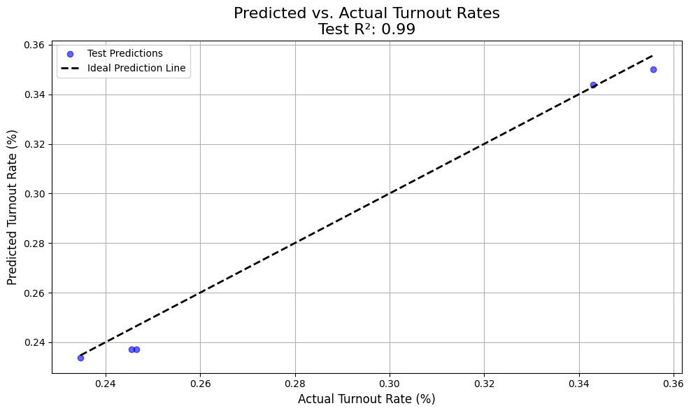

```python
# Feature Engineering: Add log-transformed and percentage change columns because we only have census updates every 10 years so need another way to simulate growth
turnout_df['log_population'] = np.log(turnout_df['population'])
turnout_df['log_total_votes'] = np.log(turnout_df['total_votes'])
turnout_df['population_vote_ratio'] = (
    turnout_df['total_votes'] / turnout_df['population']
)

# Prepare features and target
features = turnout_df[['year', 'log_population', 'log_total_votes', 'population_vote_ratio']]
target = turnout_df['turnout_rate']

# Train/test split
X_train, X_test, y_train, y_test = train_test_split(features, target, test_size=0.2, random_state=42)

# Gradient Boosting Regressor Model Training
model = GradientBoostingRegressor(random_state=42, n_estimators=100, learning_rate=0.1, max_depth=3)
model.fit(X_train, y_train)
cv_scores = cross_val_score(model, X_train, y_train, cv=5, scoring='r2')
print(f"Cross-Validation R²: {cv_scores.mean():.2f} ± {cv_scores.std():.2f}")

# Predictions
y_pred_train = model.predict(X_train)
y_pred_test = model.predict(X_test)

# Evaluation
rmse_train = np.sqrt(mean_squared_error(y_train, y_pred_train))
rmse_test = np.sqrt(mean_squared_error(y_test, y_pred_test))
r2_train = r2_score(y_train, y_pred_train)
r2_test = r2_score(y_test, y_pred_test)

print(f"Train RMSE: {rmse_train:.2f}, Test RMSE: {rmse_test:.2f}")
print(f"Train R²: {r2_train:.2f}, Test R²: {r2_test:.2f}")

plt.figure(figsize=(10, 6))
plt.scatter(y_test, y_pred_test, color='blue', alpha=0.6, label='Test Predictions')
plt.plot([y_test.min(), y_test.max()], [y_test.min(), y_test.max()], 'k--', lw=2, label='Ideal Prediction Line')
plt.title(f'Predicted vs. Actual Turnout Rates\nTest R²: {r2_test:.2f}', fontsize=16)
plt.xlabel('Actual Turnout Rate (%)', fontsize=12)
plt.ylabel('Predicted Turnout Rate (%)', fontsize=12)
plt.legend()
plt.grid(True)
plt.tight_layout()
plt.show()
```

The model explains 99% of the variance in voter turnout rates on the test data. This indicates that the features used (e.g., population, total votes, and vote-population ratios) are highly predictive of turnout rates. We also have a very low RMSE, showing a tight-fitting model. 87 percent alignment indicates some variability, however, it is still a relatively good indicator for future predictions. The scatter plots shows that our predictions are quite accurate when it comes to actual turnout rate.

**Presidential Election Prediction**

Our next machine learning method will be to create a model that can predict presidential election results based on the preceding midterm elections. Political scholars often try to use these paired election years to collect information and make predictions, however, quantitative analysis may be more robust. We will first aggregate house and senate election results during the midterms and then use a RandomForestClassifier to try and extract patterns in the data that we can reproduce in future real-world scenarios. To learn more about the principle of Random Forest Classifiers, go to this website: https://builtin.com/data-science/random-forest-algorithm#:~:text=Random%20forest%20is%20a%20predictive,other%20approaches%20would%20be%20better. We are not describing the data in this case but predicting.

```
Train Accuracy: 1.0
Test Accuracy: 0.6272727272727273

Classification Report:
               precision    recall  f1-score   support

    DEMOCRAT       0.63      0.50      0.56        52
  REPUBLICAN       0.62      0.74      0.68        58

    accuracy                           0.63       110
   macro avg       0.63      0.62      0.62       110
weighted avg       0.63      0.63      0.62       110
```

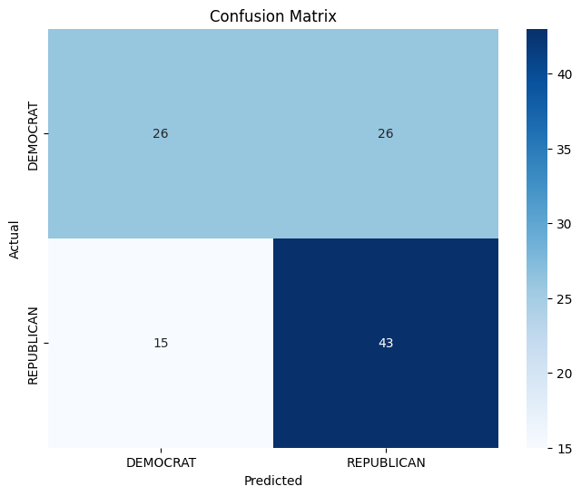

```python
# Aggregate House and Senate midterm election results
midterm_years = [year for year in range(1974, 2021, 4)]  # List of midterm election years
midterm_house = house_df[house_df['year'].isin(midterm_years)]
midterm_senate = senate_df[senate_df['year'].isin(midterm_years)]

# Combine House and Senate votes by year, state, and party
midterm_results = (
    pd.concat([midterm_house, midterm_senate])
    .groupby(['year', 'state', 'party'])['candidatevotes']
    .sum()
    .reset_index()
)

# Aggregate total votes and calculate vote shares for each party
midterm_pivot = midterm_results.pivot(index=['year', 'state'], columns='party', values='candidatevotes').fillna(0)
midterm_pivot['total_votes'] = midterm_pivot.sum(axis=1)
for party in midterm_results['party'].unique():
    midterm_pivot[f'{party}_share'] = midterm_pivot[party] / midterm_pivot['total_votes']

# Aggregate Presidential election results
presidential_results = (
    president_df.groupby(['year', 'state', 'party'])['candidatevotes']
    .sum()
    .reset_index()
)

# Identify the winning party in each state for the Presidential election
presidential_results['is_winning_party'] = (
    presidential_results.groupby(['year', 'state'])['candidatevotes'].transform('max') == presidential_results['candidatevotes']
)
presidential_results = presidential_results[presidential_results['is_winning_party']].drop(columns=['is_winning_party'])
presidential_results = presidential_results[['year', 'state', 'party']].rename(columns={'party': 'winning_party'})

# Align Presidential elections with the previous midterm elections (2 year gap between them)
presidential_results['midterm_year'] = presidential_results['year'] - 2
data = pd.merge(
    presidential_results,
    midterm_pivot.reset_index(),
    left_on=['midterm_year', 'state'],
    right_on=['year', 'state'],
    how='inner'
)

data = data.drop(columns=['year_x', 'midterm_year', 'year_y'])
label_encoder = LabelEncoder()
data['winning_party_encoded'] = label_encoder.fit_transform(data['winning_party'])
features = data.drop(columns=['state', 'winning_party', 'winning_party_encoded'])
target = data['winning_party_encoded']

# Train/Test Split, Training Random Forest Classifier
X_train, X_test, y_train, y_test = train_test_split(features, target, test_size=0.2, random_state=42)
clf = RandomForestClassifier(random_state=42, n_estimators=100)
clf.fit(X_train, y_train)

# Predictions and Evaluation
y_pred_train = clf.predict(X_train)
y_pred_test = clf.predict(X_test)

print("Train Accuracy:", accuracy_score(y_train, y_pred_train))
print("Test Accuracy:", accuracy_score(y_test, y_pred_test))
print("\nClassification Report:\n", classification_report(y_test, y_pred_test, target_names=label_encoder.classes_))

conf_matrix = confusion_matrix(y_test, y_pred_test)
plt.figure(figsize=(8, 6))
sns.heatmap(conf_matrix, annot=True, fmt='d', cmap='Blues', xticklabels=label_encoder.classes_, yticklabels=label_encoder.classes_)
plt.title("Confusion Matrix")
plt.xlabel("Predicted")
plt.ylabel("Actual")
plt.show()
```

Unfortunatley, this model does not work as well as our previous one. Train Accuracy of 1.0 indicates overfitting and test Accuracy of 0.63 shows an inability to generalize to unseen data. I don't necessarily think that this model can be improved. I think what we leearn is that midterm elections are not necessarily the best metric to predict presidential elections (in either direction). As a political science student, I can list many midterm elections that differed severly from preceeding or succeeding presidential elections. Results are far more nuanced, based on specific candidates, economic situations, and global events. Our confusion matrix also shows this intense variability.

**Presidential/Congressional Coinfluence?**

I'm also curious about how presidential candidate performance relates to house congressional performance in the same election year. As a candidate receives a greater share of the presidential vote in each state, how many house races does that candidate's party also win? To do this we will use the GradientBoostRegressor machine learning technique again. We first have to update our dataframes so we can easily extract the number of house races won per party per state per presidential election year and cross analyze this with presidential vote shares.

```python
# Filter for presidential election years
presidential_years = president_df['year'].unique()
presidential_years = [year for year in presidential_years if year % 4 == 0]

# Aggregate presidential election performance at the state level
state_presidential = (
    president_df[president_df['year'].isin(presidential_years)]
    .groupby(['state', 'year', 'party'])['candidatevotes']
    .sum()
    .reset_index()
)

# Calculate vote shares for Democrats and Republicans
state_presidential = state_presidential.pivot(
    index=['state', 'year'], columns='party', values='candidatevotes'
).fillna(0)
state_presidential['total_votes'] = state_presidential.sum(axis=1)
state_presidential['dem_share'] = state_presidential['DEMOCRAT'] / state_presidential['total_votes']
state_presidential['rep_share'] = state_presidential['REPUBLICAN'] / state_presidential['total_votes']
state_presidential.reset_index(inplace=True)

# Filter data for presidential election years
house_presidential_years = house_df[house_df['year'].isin(presidential_years)]

# Determine the winning party for each district
house_presidential_years['is_winning_party'] = (
    house_presidential_years.groupby(['year', 'state', 'district'])['candidatevotes']
    .transform('max') == house_presidential_years['candidatevotes']
)

# Filter only rows where the party won
winning_house = house_presidential_years[house_presidential_years['is_winning_party']]

# Count wins for each party by state and year
state_congressional = (
    winning_house.groupby(['state', 'year', 'party'])
    .size()
    .unstack(fill_value=0)
    .reset_index()
    .rename(columns={'DEMOCRAT': 'dem_wins', 'REPUBLICAN': 'rep_wins'})
)

state_congressional.reset_index(inplace=True)

# Merge presidential performance and congressional wins
data = pd.merge(state_presidential, state_congressional, on=['state', 'year'], how='inner')
```

Now that we have properly prepared and transformed our data, we will train and test our models for the two major parties.

```python
# Features and targets
features = data[['dem_share', 'rep_share']]
target_dem = data['dem_wins']
target_rep = data['rep_wins']

# Train/test split
X_train, X_test, y_train_dem, y_test_dem = train_test_split(features, target_dem, test_size=0.2, random_state=42)
_, _, y_train_rep, y_test_rep = train_test_split(features, target_rep, test_size=0.2, random_state=42)

# Train models for Democratic and Republican wins
model_dem = GradientBoostingRegressor(random_state=42)
model_rep = GradientBoostingRegressor(random_state=42)

model_dem.fit(X_train, y_train_dem)
model_rep.fit(X_train, y_train_rep)

# Predictions
data['predicted_dem_wins'] = model_dem.predict(features)
data['predicted_rep_wins'] = model_rep.predict(features)

# Evaluate models
print("Democratic Wins Model R²:", r2_score(target_dem, data['predicted_dem_wins']))
print("Republican Wins Model R²:", r2_score(target_rep, data['predicted_rep_wins']))
```

```
Democratic Wins Model R²: 0.5812045877820247
Republican Wins Model R²: 0.44249332388180096
```

These R2 coefficient values show that it's not a simple linear relationship that that we need to look at more advanced regression techniques. It's vital to know what type of regression will best work with your data as you do a machine learning project. You will see in the following few code boxes that I test a couple different regressions before I settle on which one I think works best. To learn more about what regression to use when, read here: https://statisticsbyjim.com/regression/choosing-regression-analysis/.

```python
# Calculate average congressional seats won by proportion of presidential vote
data['dem_share_bins'] = pd.cut(data['dem_share'], bins=10)
data['rep_share_bins'] = pd.cut(data['rep_share'], bins=10)

# Calculate averages for each bin
dem_response = data.groupby('dem_share_bins').agg({
    'dem_share': 'mean',
    'dem_wins': 'mean'
}).reset_index()

rep_response = data.groupby('rep_share_bins').agg({
    'rep_share': 'mean',
    'rep_wins': 'mean'
}).reset_index()
```

Scatterplot to observe the relationship between presidential vote share and congressoinal seats won per state averaged nationally (one line per each of the two major parties).

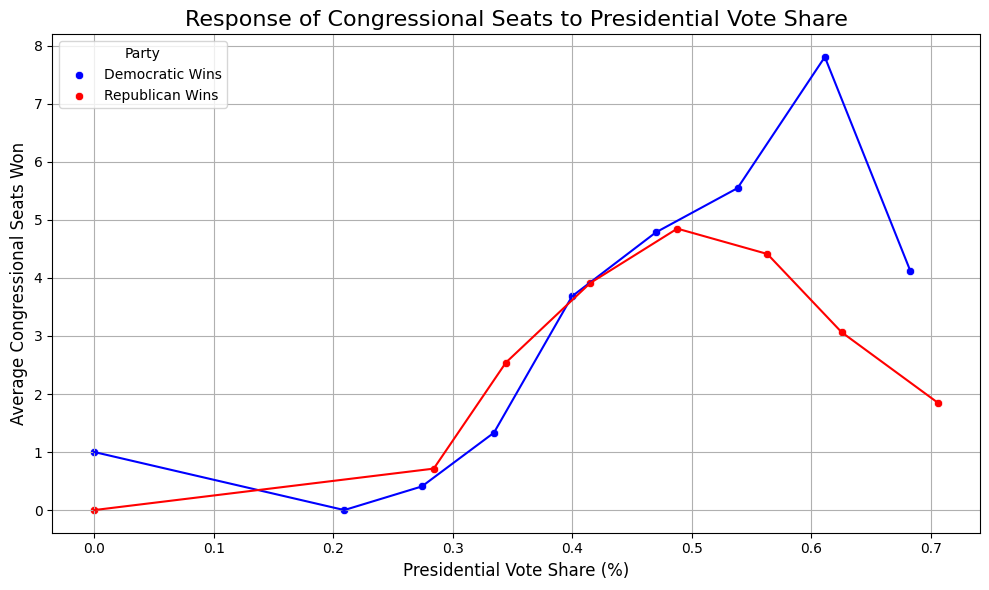

```python
# Dems
plt.figure(figsize=(10, 6))
sns.scatterplot(data=dem_response, x='dem_share', y='dem_wins', color='blue', label='Democratic Wins')
sns.lineplot(data=dem_response, x='dem_share', y='dem_wins', color='blue')

# Reps
sns.scatterplot(data=rep_response, x='rep_share', y='rep_wins', color='red', label='Republican Wins')
sns.lineplot(data=rep_response, x='rep_share', y='rep_wins', color='red')

plt.title('Response of Congressional Seats to Presidential Vote Share', fontsize=16)
plt.xlabel('Presidential Vote Share (%)', fontsize=12)
plt.ylabel('Average Congressional Seats Won', fontsize=12)
plt.legend(title='Party')
plt.grid(True)
plt.tight_layout()
plt.show()
```

The way that I would explain the diminishing returns and later decrease in the average congressional seats won per party as their presidential vote share increases is that very small states start to skew the numbers. Smaller states with very little congressional representation like Rhode Island, Connecticut, Idaho, and others are usually more partisan than larger states like Texas but have far fewer seats.

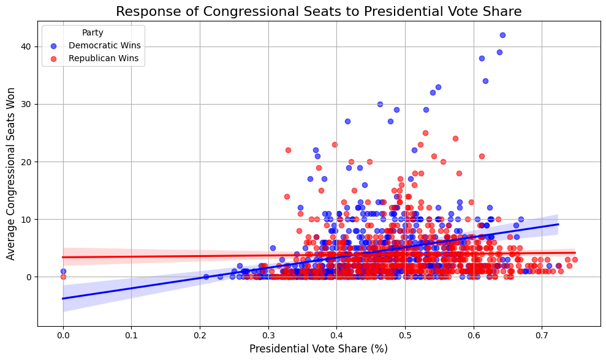

```python
# Create the scatterplot with regression lines for both parties
plt.figure(figsize=(10, 6))

# Dems
sns.regplot(
    data=data,
    x='dem_share',
    y='dem_wins',
    scatter_kws={'color': 'blue', 'alpha': 0.6},
    line_kws={'color': 'blue'},
    label='Democratic Wins'
)

# Reps
sns.regplot(
    data=data,
    x='rep_share',
    y='rep_wins',
    scatter_kws={'color': 'red', 'alpha': 0.6},
    line_kws={'color': 'red'},
    label='Republican Wins'
)

plt.title('Response of Congressional Seats to Presidential Vote Share', fontsize=16)
plt.xlabel('Presidential Vote Share (%)', fontsize=12)
plt.ylabel('Average Congressional Seats Won', fontsize=12)
plt.legend(title='Party')
plt.grid(True)
plt.tight_layout()
plt.show()
```

This is quite a confusing graphic. We see lots of outliers and clustering. The regression lines do seem to get close to our densest data regions, however, it's clear that a linear model will not work best for this (as we observed with our previous R2 values). Let's try polynomial regressions instead.

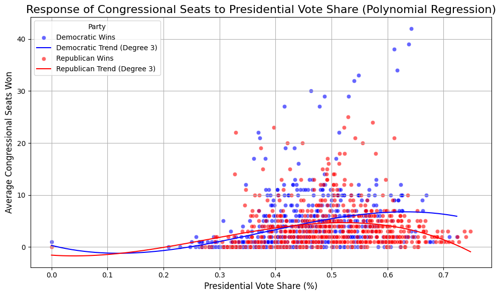

```python
# Polynomial Regression Function
def plot_polynomial_regression(x, y, degree, color, label):
    # Fit polynomial regression
    coeffs = np.polyfit(x, y, degree)
    poly = Polynomial(coeffs[::-1])  # Reverse coefficients for Polynomial
    x_range = np.linspace(x.min(), x.max(), 500)
    y_pred = poly(x_range)

    # Plot regression line
    plt.plot(x_range, y_pred, color=color, label=f'{label} (Degree {degree})')

# Create the scatterplot with polynomial regression for both parties
plt.figure(figsize=(10, 6))

# Scatter and polynomial regression for Democrats
sns.scatterplot(x='dem_share', y='dem_wins', data=data, color='blue', alpha=0.6, label='Democratic Wins')
plot_polynomial_regression(data['dem_share'], data['dem_wins'], degree=3, color='blue', label='Democratic Trend')

# Scatter and polynomial regression for Republicans
sns.scatterplot(x='rep_share', y='rep_wins', data=data, color='red', alpha=0.6, label='Republican Wins')
plot_polynomial_regression(data['rep_share'], data['rep_wins'], degree=3, color='red', label='Republican Trend')

# Chart customization
plt.title('Response of Congressional Seats to Presidential Vote Share (Polynomial Regression)', fontsize=16)
plt.xlabel('Presidential Vote Share (%)', fontsize=12)
plt.ylabel('Average Congressional Seats Won', fontsize=12)
plt.legend(title='Party')
plt.grid(True)
plt.tight_layout()
plt.show()
```

Before trying the degree three polynomial regression, I tried a degree two. I omitted that part because I think three works better fo this data (indicating how eventually the average number of seats won will decrease in those smaller partisan states). This is an example of how fitting and choosing your model is not always based on numbers but some situational and field-based understanding. The reason our models don't go higher to the points above is they are further from the denser center (though not necessarily outliers). Thus, we can conclude the relationship between presidential vote share and congressional seats one is more of a cubic shape across the past half century of election data.

# Conclusions and Policy Suggestions

**From EDA**

Overall, we've learned much about election dynamics and voting patterns from both our exploratory data anlaysis and machine learning/visualization. From EDA, we established that beyond anything else, politics is fickle. Whether it comes to midterm and presidential election years, nationwide party performance in a single year, and more, we can't always determine if there are statistical relationships. However, we do see that Democrats traditionally have experienced more extreme maxima relative to the Republicans and have overall higher vote sums on average. However, this popularity does not always translate into electoral victories because of overrepresentation in both the sentate, congress, and electoral college for smaller Republican states. What this tells me most is that we must focus on election victories for substantial policy recommendations. Another interesting thing to note from EDA was that Republicans are gaining on (or have suprassed) Democrats when it comes to total house election votes. This is not mirrored in the senate. A question that we can pose to political scientists or strategists is why is this happening? They must focus on the smallest districts and see why GOP members have attracted more voters than in the best. Are the Democrats proving to be a more federal/statewide party and neglecting the interests of their local constituencies?

**From ML**

When it comes to our Machine Learning section, we gleaned several insights that can help politicians and campaigns over the next few elections.

Voter Turnout

Midterm/Presidential Cycle Prediction

Presidential vs. Congressional Partisan Performance

- This is the ML method that I found most interesting during this project. Political scientists and journalists always like to talk about the carryover effect that top of ticket candidates can have down the ballot. In 2024, this effect was seemingly more nebulous as gubernatorial, house, and senate races all broke with how voters made their presidential choice. Our initial plots and regressions show something incredibly interesting: house performance in states on average increase for a party as that party's presidnetial candidate receives a larger share of the vote. However, this eventually tapers of and begins to decrease with very high levels of presidential vote share (most likely due to partisanship in small, less populated states as I previously mentioned). Our regression also shows a cubic fit, with a similar peak and eventual decrease in average house seats won when presidential vote share goes up. I suggest that the Democrats invest in both presidential and house campaign advertisements in competitive districts because their top-of-ticket effect is even stronger than Republicans. Republicans should also make this investment, but probably won't benefit as much as Democratic candidates will. Additionally, this cubic fit shows that parties should avoid trying to win enclave districts (one or two districts that vote for one party in a state that as a whole goes mostly for the opposite party) because even as the presidential share goes up these districts remain brittle. Instead, attention show go to battleground states and states where a candidate has 10 to 20 percentage points more than their opponent (for whichever party is in the lead).

Overall

- Political Science and politics are extremely hard to predict even with the most advanced models. That being said, advanced machine learning models can sometimes cut through supposition and show clear voter/election trends that can help parties restructure and optimize. The 2024 election defied many expectations on both sides of the aisle and proves the need for more data analysis in the field of politics.